# IA para Científicos Sociales

Sesión 3.1: Clustering y reducción de dimensionalidad

Danilo Freire

danilofreire@gmail.com

Departament of Data and Decision Sciences  
Emory University

# Día 3: Texto y aprendizaje no supervisado

## Repaso del Día 2

- Regresión logística: interpretable, produce probabilidades
- Árboles de decisión: intuitivos pero sobreajustan
- Random Forest: combina muchos árboles para mejor predicción
- Predicción vs. explicación: dos objetivos diferentes en ciencias sociales
- Regularización: LASSO selecciona variables, Ridge reduce coeficientes
- `tidymodels` permite comparar modelos con la misma sintaxis

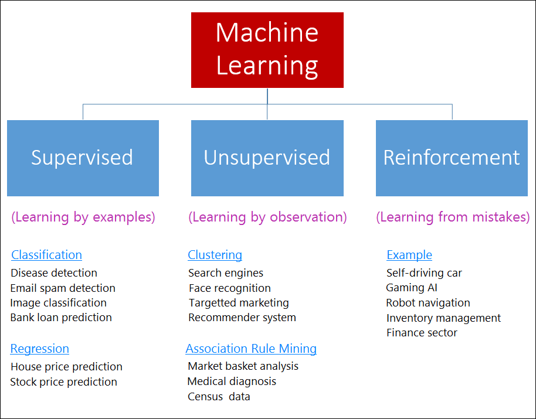

## Agenda de la sesión

**Primera parte: clustering**

- ¿Qué es el aprendizaje no supervisado?
- K-means: algoritmo y limitaciones
- Elegir K: método del codo y silueta
- Ejemplo práctico en R
- Clustering jerárquico y comparación

**Segunda parte: PCA**

- Reducción de dimensionalidad: PCA
- ¿Cuántos componentes conservar?
- Interpretación de loadings y biplot
- Aplicaciones en América Latina

# ¿Qué es el aprendizaje no supervisado?

## Aprender sin etiquetas

- En aprendizaje supervisado, teníamos respuestas correctas (etiquetas)
- En aprendizaje no supervisado, no hay etiquetas
- El modelo debe descubrir patrones ocultos en los datos por sí mismo
- ¿Por qué usarlo?
  - Las etiquetas son costosas (requieren expertos)
  - A veces las etiquetas no existen (“¿cuántos tipos de votantes hay?”)
  - Exploración: entender los datos antes de modelar
- Dos técnicas principales:
  - Clustering: agrupar observaciones similares
  - Reducción de dimensionalidad: simplificar datos con muchas variables

# K-means

## ¿Qué es K-means?

- K-means: el algoritmo de clustering más popular
- Particiona los datos en K grupos (clusters)
- Los puntos dentro del mismo cluster son similares entre sí
- Los puntos en clusters diferentes son disimilares
- ¿Cómo funciona?
  1. Elegir K centros aleatoriamente
  2. Asignar cada punto al centro más cercano
  3. Mover cada centro al promedio de sus puntos asignados
  4. Repetir pasos 2-3 hasta que los centros no se muevan
- Simple, rápido y funciona bien en muchos casos

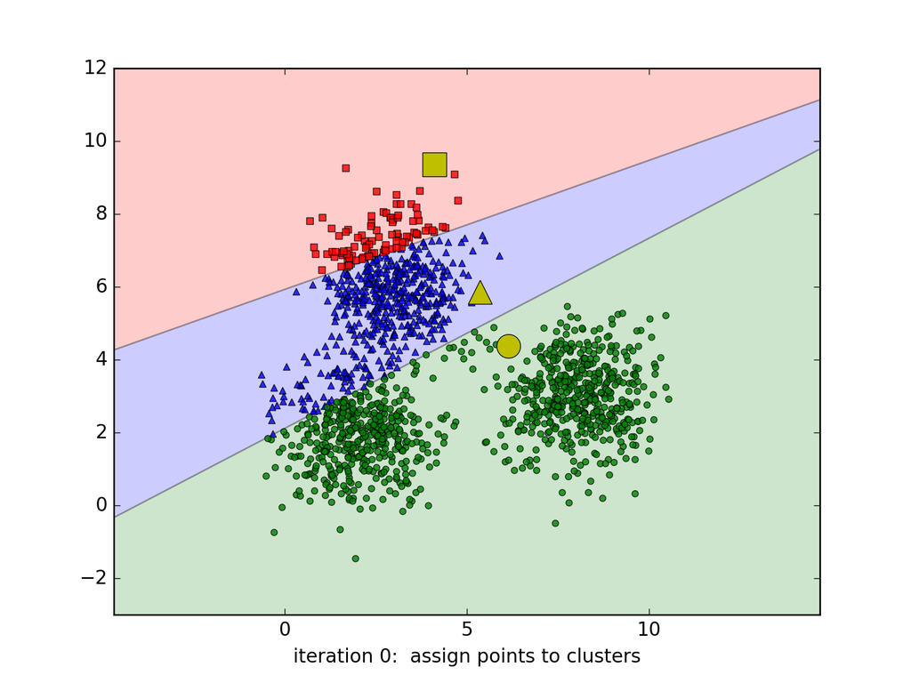

K-means en acción

Fuente: [Machine Learning CoBan](https://machinelearningcoban.com/2017/01/01/kmeans/)

## ¿Cómo elegir K?

- El usuario debe elegir el número de clusters (K) de antemano
- No existe un K “correcto” en general
- Métodos para orientarse:
  - Método del codo: graficar la suma de distancias internas para diferentes K, buscar el “codo” donde la mejora se estabiliza
  - Silueta: mide qué tan bien cada punto encaja en su cluster. Valores altos (cercanos a 1) son buenos
  - Conocimiento del dominio: ¿cuántos grupos tienen sentido teóricamente?
- En ciencias sociales, el contexto teórico suele ser más importante que las métricas estadísticas
- Ejemplo: ¿cuántos “tipos” de regímenes políticos hay? ¿3? ¿5? ¿7? Depende de la teoría

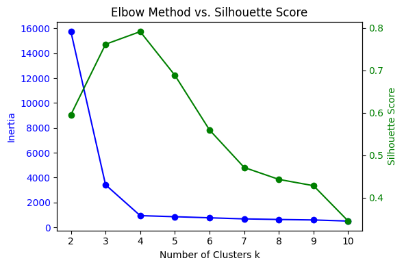

Método del codo y silueta

Codo: Se elige el K donde la curva “se aplana”: agregar más clusters ya no mejora mucho

Silueta: Valores altos (cercanos a 1) indican mejor ajuste

## Limitaciones de K-means

**Supuestos que hace**

- Los clusters son esféricos (todos del mismo tamaño)
- Cada punto pertenece a un solo cluster
- Sensible a la escala de las variables (siempre normalizar antes)
- Sensible a los valores iniciales (ejecutar varias veces)

**Aplicaciones en ciencias sociales**

- Segmentación de países: agrupar países por indicadores de desarrollo
- Tipología de votantes: identificar perfiles electorales
- Clasificación de municipios: agrupar por características socioeconómicas
- Análisis de encuestas: encontrar grupos de respuesta similares

K-means es un punto de partida, no el final. Sirve para explorar los datos y generar hipótesis, no para confirmar teorías causales.

# Evaluación de clusters

## Coeficiente de silueta

- El coeficiente de silueta mide qué tan bien cada observación encaja en su cluster
- Para cada punto $i$:
  - $a(i)$ = distancia promedio a otros puntos del mismo cluster
  - $b(i)$ = distancia promedio al cluster más cercano diferente

$$s(i) = \frac{b(i) - a(i)}{\max(a(i), b(i))}$$

- Valores de $s(i)$:
  - Cerca de +1: el punto está bien clasificado
  - Cerca de 0: el punto está en el borde entre clusters
  - Cerca de -1: el punto probablemente está en el cluster equivocado

**Interpretación del promedio de silueta:**

| Valor | Interpretación |
| --- | --- |
| 0.71 - 1.00 | Estructura fuerte |
| 0.51 - 0.70 | Estructura razonable |
| 0.26 - 0.50 | Estructura débil |
| < 0.25 | Sin estructura clara |

Podemos usar la silueta promedio para elegir K: el K con mayor silueta indica clusters mejor definidos.

## Método de la silueta para elegir K

**Ventajas sobre el método del codo**

- Mide calidad (qué tan separados están los clusters), no solo compacidad interna
- Escala interpretable: cerca de 1 indica clusters bien definidos, cerca de 0 clusters solapados
- El máximo suele ser más fácil de identificar que un “codo” ambiguo

**Advertencias**

- Tiende a favorecer valores pequeños de K: a veces elige K=2 aunque existan 4 grupos reales, si esos 4 son menos “limpios”
- Si dos K dan siluetas similares, preferir el menor (parsimonia) o el que tenga más sentido teórico
- Combinar siempre con conocimiento del dominio y con el método del codo

**Ejemplo**

```
Silueta promedio por K:

K=2:  0.52
K=3:  0.58  ← máximo
K=4:  0.51
K=5:  0.44
K=6:  0.38

La silueta sugiere K=3.
El método del codo podría
sugerir otro valor.

Usar ambos + teoría para decidir.
```

## K-means en R: simulando datos

Simulamos 90 “países” organizados en 3 tipos de desarrollo (alto, medio, bajo), con 4 indicadores estandarizados y correlacionados entre sí.

**Variables** (todas en z-score):

- `pib`: producto interno bruto per cápita
- `educ`: años promedio de escolaridad
- `internet`: acceso a internet
- `desigualdad`: índice tipo Gini
- `grupo_real`: grupo verdadero, para verificar si K-means lo recupera

Desigualdad no es monótona: alta en países de ingreso medio, baja en los extremos. Refleja patrones reales en América Latina

```r
R> glimpse(datos)
```

```
Rows: 90
Columns: 5
$ pib         <dbl> 1.757936, 3.364688, 2.219472, 2.799533, 3.091635, 5.077923…
$ educ        <dbl> 0.9310475, 4.2105916, 2.1411508, 3.1483019, 1.6691161, 3.7…
$ internet    <dbl> 3.0216210, 2.6016175, 2.7453670, 2.3151813, 4.5646070, 4.2…
$ desigualdad <dbl> -0.6457693, -0.7003951, -0.9898428, -1.5293797, -0.9875592…
$ grupo_real  <chr> "alto", "alto", "alto", "alto", "alto", "alto", "alto", "a…
```

## K-means en R: ajuste y evaluación

```r
R> library(cluster)
R> library(factoextra)
R>
R> # Escalar (siempre antes de K-means)
R> datos_scaled <- datos |>
+   dplyr::select(where(is.numeric)) |>
+   scale()
R>
R> # Ajustar K-means con K=3 y 25 inicializaciones aleatorias
R> km <- kmeans(datos_scaled, centers = 3, nstart = 25)
R>
R> # Silueta promedio
R> sil <- silhouette(km$cluster, dist(datos_scaled))
R> round(mean(sil[, 3]), 3)
```

```
[1] 0.553
```

```r
R> # ¿Recuperó los grupos reales?
R> table(real = datos$grupo_real, cluster = km$cluster)
```

```
       cluster
real     1  2  3
  alto  29  0  1
  bajo   0 30  0
  medio  0  1 29
```

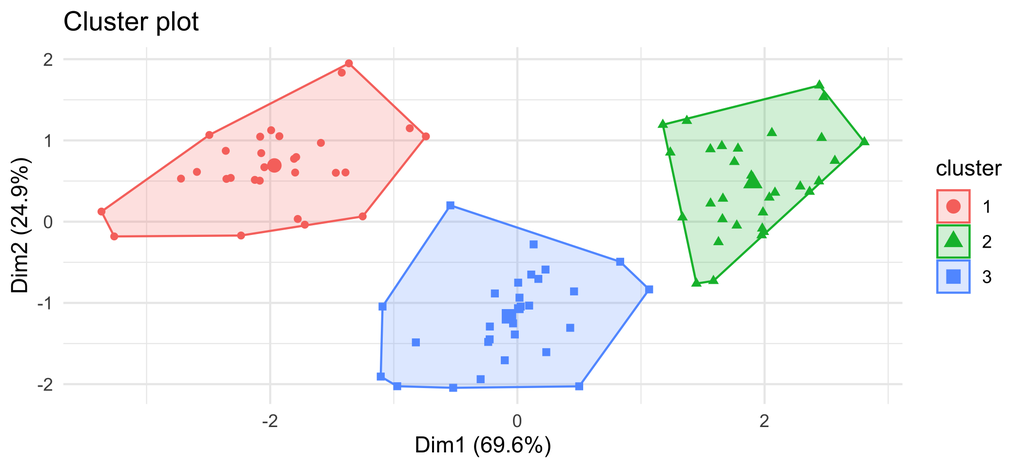

```r
R> fviz_cluster(km, data = datos_scaled, geom = "point",
+              ellipse.type = "convex") +
+   theme_minimal(base_size = 11)
```

- `nstart = 25` protege contra mínimos locales por una mala inicialización aleatoria

## K-means en R: eligiendo K

¿Cómo supimos que K=3 era la mejor opción? Aplicando los dos métodos a los datos simulados:

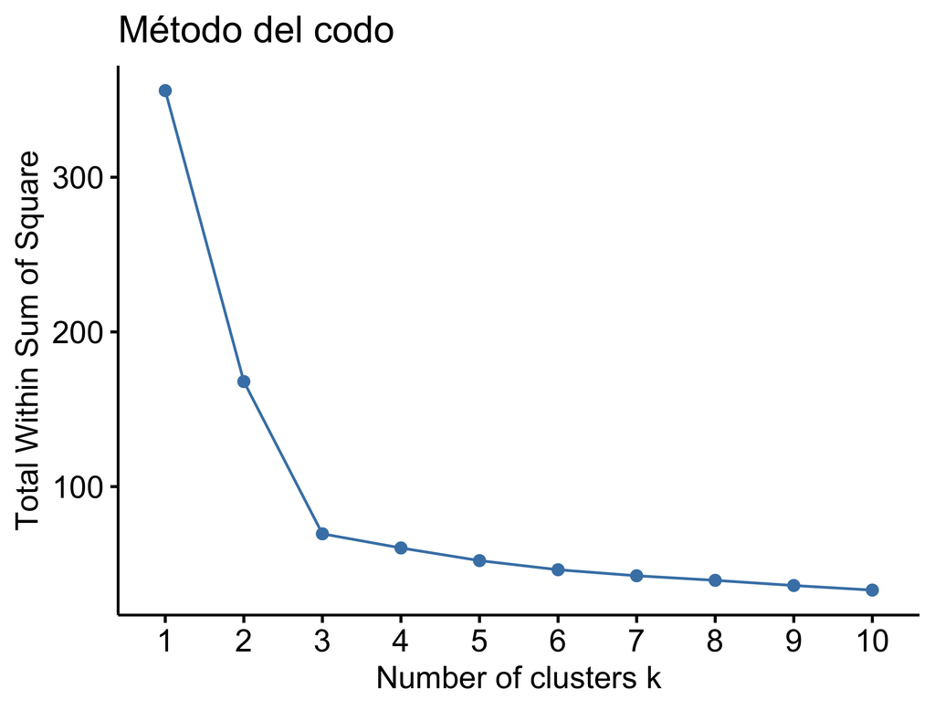

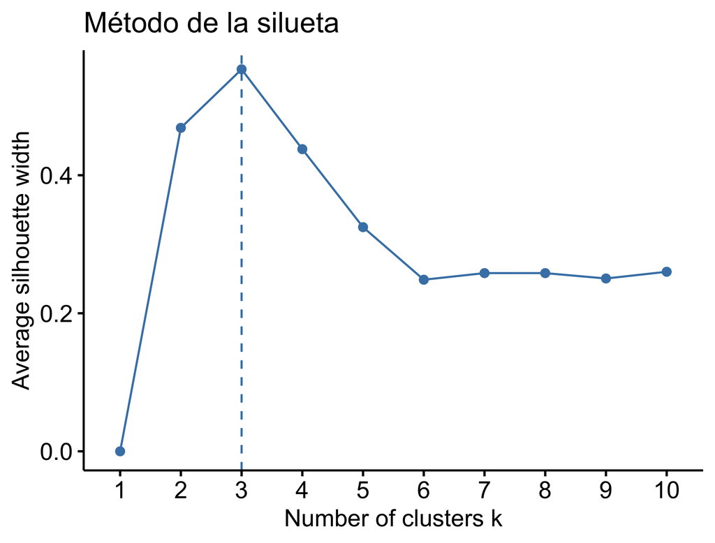

```r
R> fviz_nbclust(datos_scaled, kmeans, method = "wss", nstart = 25) +
+   labs(title = "Método del codo", subtitle = NULL)
R> fviz_nbclust(datos_scaled, kmeans, method = "silhouette", nstart = 25) +
+   labs(title = "Método de la silueta", subtitle = NULL)
```

- **Izquierda**: la suma de distancias internas (within sum of squares) cae bruscamente hasta K=3 y se aplana después. El codo está en K=3.
- **Derecha**: la silueta promedio se maximiza en K=3, confirmando el diagnóstico.
- Ambos métodos coinciden porque los datos tienen estructura clara. En aplicaciones reales suelen discrepar, y ahí pesa la teoría.

# Clustering jerárquico

## ¿Qué es el clustering jerárquico?

- Clustering jerárquico: crea una jerarquía de clusters anidados
- No requiere especificar K de antemano
- Dos enfoques:
  - Aglomerativo (bottom-up): empieza con cada punto como cluster y fusiona los más cercanos
  - Divisivo (top-down): empieza con todos los puntos juntos y los va dividiendo
- El resultado se visualiza como un dendrograma
- El usuario “corta” el dendrograma al nivel deseado para obtener K clusters
- Tomamos 3 países de cada grupo de los datos simulados para ilustrar:

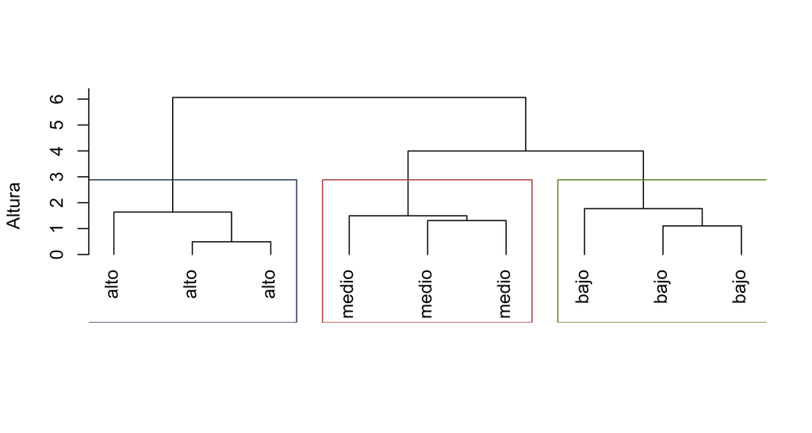

```r
R> set.seed(2026)
R> muestra <- datos |>
+   group_by(grupo_real) |>
+   slice_sample(n = 3) |>
+   ungroup()
R>
R> m_scaled <- scale(muestra[, 1:4])
R> rownames(m_scaled) <- muestra$grupo_real
R>
R> hc_demo <- hclust(dist(m_scaled), method = "ward.D2")
R> plot(hc_demo, hang = -1, main = "", xlab = "",
+               sub = "", ylab = "Altura")
R> rect.hclust(hc_demo, k = 3,
+             border = c("#2d4563", "#b85450", "#6b8e23"))
```

## Métodos de enlace (linkage)

| Método | Distancia entre clusters | Características |
| --- | --- | --- |
| Single (mínimo) | Puntos más cercanos | Puede crear cadenas largas |
| Complete (máximo) | Puntos más lejanos | Clusters compactos |
| Average (promedio) | Promedio de todas las distancias | Balance entre ambos |
| Ward | Minimiza varianza interna | Similar a K-means, muy usado |

- Ward es el más usado en ciencias sociales porque tiende a crear clusters de tamaño similar
- En R: `hclust(dist(datos), method = "ward.D2")`

## Clustering jerárquico en R

Reutilizamos los mismos datos simulados (`datos_scaled`) para comparar con K-means:

```r
R> # Matriz de distancias y clustering jerárquico con método Ward
R> d <- dist(datos_scaled, method = "euclidean")
R> hc <- hclust(d, method = "ward.D2")
R>
R> # Cortar para obtener 3 clusters
R> grupos_hc <- cutree(hc, k = 3)
R>
R> # ¿Recuperó los grupos reales?
R> table(real = datos$grupo_real, cluster = grupos_hc)
```

```
       cluster
real     1  2  3
  alto  29  1  0
  bajo   0  0 30
  medio  0 28  2
```

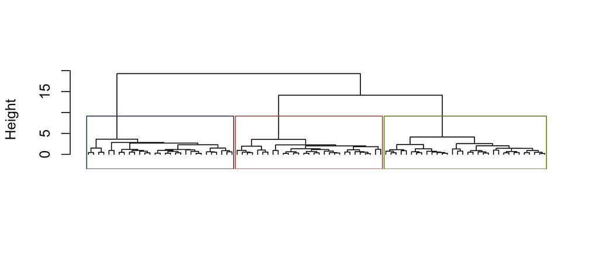

```r
R> # Dendrograma con los 3 cortes resaltados
R> plot(hc, hang = -1, labels = FALSE, main = "", xlab = "", sub = "")
R> rect.hclust(hc, k = 3, border = c("#2d4563", "#b85450", "#6b8e23"))
```

- La tabla confirma que Ward recupera los 3 grupos casi perfectamente. El dendrograma permite explorar otros cortes (2, 4, 5, …) sin reajustar el modelo

## K-means vs. Jerárquico

| Criterio | K-means | Jerárquico |
| --- | --- | --- |
| Elegir K | Antes de ejecutar | Después (cortando) |
| Forma de clusters | Esféricos | Cualquier forma |
| Escalabilidad | Muy rápido | Lento para n grande |
| Reproducibilidad | Depende de inicialización | Determinístico |
| Visualización | Scatter plot | Dendrograma |
| Jerarquía | No | Sí (anidamiento) |

- Use K-means para datasets grandes cuando tiene una idea del número de grupos
- Use jerárquico para explorar la estructura de los datos y visualizar relaciones entre observaciones

# PCA: Reducción de dimensionalidad

## ¿Qué es PCA?

- PCA (Principal Component Analysis / Análisis de Componentes Principales)
- Problema: tenemos muchas variables y queremos simplificar
- PCA busca las direcciones de máxima variación en los datos
- Crea nuevas variables (componentes principales) que son combinaciones lineales de las originales
- Primer componente: la dirección con más varianza
- Segundo componente: la siguiente dirección con más varianza, perpendicular al primero
- Y así sucesivamente
- Permite visualizar datos de alta dimensión en 2D o 3D

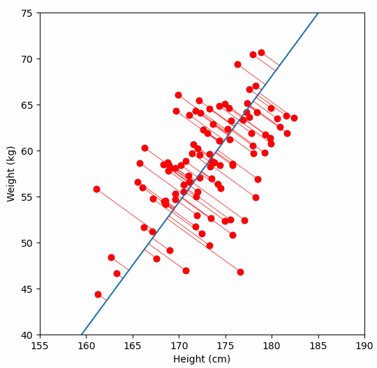

PCA: encontrar las direcciones de máxima varianza

Fuente: [Vizuara](https://www.vizuaranewsletter.com/p/understanding-principal-component)

## ¿Para qué sirve PCA en ciencias sociales?

- Visualización: reducir 8 variables a 2 dimensiones para graficar
- Construcción de índices: combinar muchos indicadores en uno solo
  - Ejemplo: el Índice de Desarrollo Humano (IDH) combina esperanza de vida, educación e ingreso en un solo número, que es la misma idea de PCA (aunque el IDH usa una media geométrica, no componentes principales)
- Preprocesamiento: reducir la dimensionalidad antes de aplicar otro modelo (como K-means o regresión)
- Detección de patrones: ver qué variables “van juntas”
  - Si el primer componente carga fuertemente en PIB, educación e internet, lo podemos interpretar como un “eje de desarrollo”

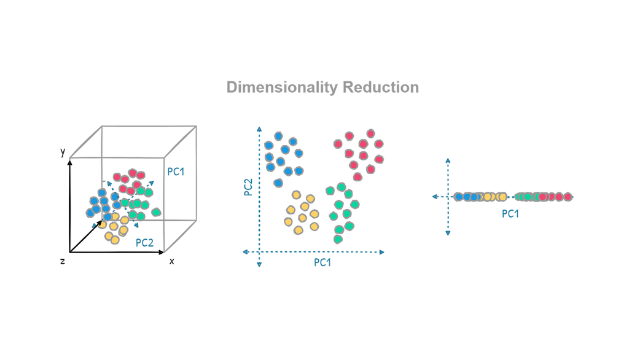

Fuente: [Medium](https://muhammadtaha01.medium.com/dimensionality-reduction-in-machine-learning-46d45747eaee)

## ¿Cuántos componentes conservar?

- PCA produce tantos componentes como variables originales. Criterios para conservar los primeros: varianza acumulada ~80%, método del codo, regla de Kaiser (eigenvalue > 1)

```r
R> library(factoextra)
R> pca <- prcomp(datos_scaled)
R>
R> fviz_eig(pca, addlabels = TRUE,
+          barfill = "steelblue",
+          barcolor = "steelblue") +
+   labs(title = NULL,
+        y = "Varianza (%)") +
+   theme_minimal(base_size = 10) +
+   coord_cartesian(ylim = c(0, 100))
```

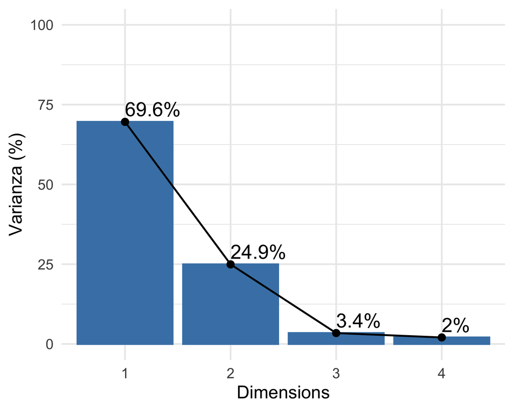

- PC1 captura la mayor parte de la varianza (eje de desarrollo: PIB, educación e internet covarían). Con 2 componentes ya explicamos más del 80% del total

## Interpretación de los loadings

**Idea intuitiva:** cada componente es una receta que combina las variables originales. Los loadings son la cantidad de cada ingrediente.

- Grande (cerca de ±1): la variable pesa mucho
- Cerca de cero: la variable casi no aparece
- Mismo signo dentro de un PC: las variables suben y bajan juntas
- Signos opuestos: van en direcciones contrarias
- El signo global del PC es arbitrario: si lo invertimos, el resultado es equivalente

```r
R> # Loadings (matriz de rotación)
R> round(pca$rotation, 2)
```

```
              PC1   PC2   PC3   PC4
pib         -0.58  0.02  0.04  0.81
educ        -0.57 -0.01  0.68 -0.45
internet    -0.57  0.12 -0.72 -0.38
desigualdad -0.07 -0.99 -0.09 -0.02
```

```r
R> # Varianza explicada
R> summary(pca)$importance |> round(2)
```

```
                        PC1  PC2  PC3  PC4
Standard deviation     1.67 1.00 0.37 0.29
Proportion of Variance 0.70 0.25 0.03 0.02
Cumulative Proportion  0.70 0.95 0.98 1.00
```

**Leyendo nuestros resultados:**

- PC1: PIB, educación e internet pesan casi igual (~-0.57 cada uno); desigualdad casi no pesa. PC1 resume el desarrollo general del país
- PC2: desigualdad pesa casi todo (-0.99) y las demás casi nada. PC2 captura solo la desigualdad
- Entre PC1 y PC2 explican el 95% de la varianza

## Biplot: visualización combinada

Un biplot muestra simultáneamente las observaciones (puntos) y las variables (flechas). Flechas cercanas indican variables correlacionadas; las observaciones en la dirección de una flecha tienen valores altos en esa variable.

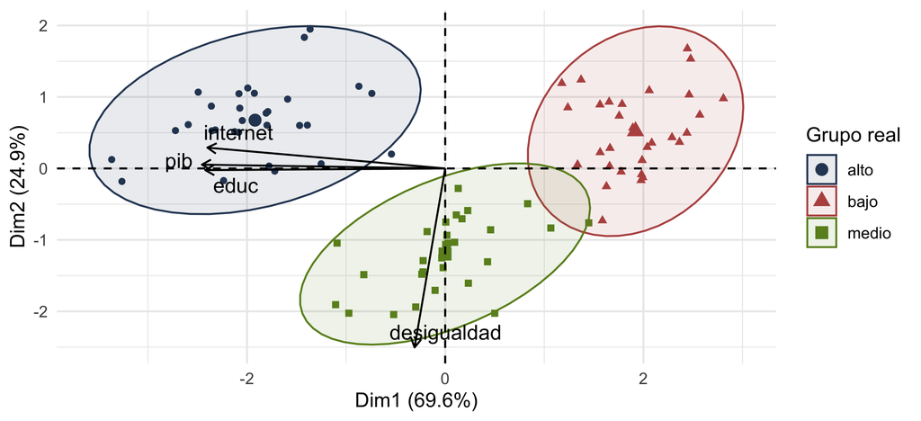

```r
R> fviz_pca_biplot(pca,
+                 geom.ind = "point",
+                 habillage = datos$grupo_real,
+                 addEllipses = TRUE,
+                 palette = c("#2d4563", "#b85450", "#6b8e23"),
+                 col.var = "black",
+                 repel = TRUE,
+                 legend.title = "Grupo real") +
+   labs(title = NULL) +
+   theme_minimal(base_size = 11)
```

- Los tres grupos simulados se separan con claridad en el plano PC1-PC2. Las flechas confirman que PIB, educación e internet apuntan juntas, y desigualdad va en dirección distinta

## PCA: lo que hay que recordar

**Ventajas**

- Reduce la dimensionalidad preservando la mayor varianza posible
- Ayuda a visualizar datos complejos
- Puede revelar estructura latente
- Los componentes son no correlacionados entre sí (ortogonales, es decir, su correlación es cero)
- No necesita etiquetas

**Limitaciones**

- Sólo captura relaciones lineales
- Los componentes son difíciles de interpretar (son combinaciones de muchas variables)
- Sensible a la escala: siempre normalizar antes
- No es un modelo causal: no dice por qué las variables están correlacionadas
- ¿Cuántos componentes conservar? Regla general: los que explican ~80% de la varianza

# Aplicaciones en ciencias sociales

## Aplicaciones y lecturas clave

**Dónde se usan estas técnicas:**

- Tipologías de países por indicadores de desarrollo, gobernanza e institucionalidad
- Mapas ideológicos de partidos y legisladores
- Segmentación de votantes a partir de encuestas (Latinobarómetro, LAPOP)
- Índices compuestos (desarrollo humano, capital social, calidad institucional)
- Preprocesamiento antes de una regresión con variables correlacionadas
- Agrupación de respuestas abiertas en encuestas grandes

**Lecturas recomendadas:**

- Hotelling, H. (1933). [“Analysis of a complex of statistical variables into principal components.”](https://doi.org/10.1037/h0071325) *Journal of Educational Psychology*, 24(6)
- Ahlquist, J. S. & Breunig, C. (2012). [“Model-based clustering and typologies in the social sciences.”](https://doi.org/10.1093/pan/mpr039) *Political Analysis*, 20(1)
- Jolliffe, I. T. & Cadima, J. (2016). [“Principal component analysis: a review and recent developments.”](https://doi.org/10.1098/rsta.2015.0202) *Phil. Trans. R. Soc. A*, 374
- Grimmer, J., Roberts, M. E. & Stewart, B. M. (2022). [*Text as Data*.](https://press.princeton.edu/books/hardcover/9780691207544/text-as-data) Princeton University Press

En el laboratorio (Sesión 3.3) aplicaremos estas técnicas a datos reales de países latinoamericanos.

## PCA vs. análisis factorial

Muchos índices que usamos en ciencias sociales (bienestar, confianza institucional, autoritarismo) parecen PCA pero son análisis factorial. Son parientes cercanos que responden a preguntas distintas.

**PCA**

- No asume un modelo: busca ejes que explican varianza
- Los componentes son sumas ponderadas de las variables observadas
- Cada PC intenta captar la máxima varianza posible, sin separar “error”
- Pregunta: ¿cómo resumo estos datos?

**Análisis factorial**

- Asume un modelo: variables observadas = factores latentes + error
- Los factores son causas hipotéticas que generan las correlaciones
- Estima por separado la varianza común y la específica de cada variable
- Pregunta: ¿qué constructos latentes explican estas variables?

Regla práctica: si vas a reportar un índice como “medida de X” (una actitud, un constructo), probablemente querés análisis factorial. Si solo querés reducir dimensiones para visualizar o graficar, PCA alcanza.

## Cómo caracterizar un cluster en la práctica

Después de correr `kmeans()`, la etiqueta `1/2/3` no significa nada por sí misma. Hay que darle contenido sustantivo:

**1. Perfiles por cluster:** calcular la media de cada variable dentro de cada grupo

```r
R> datos |>
+   mutate(cluster = km$cluster) |>
+   group_by(cluster) |>
+   summarise(across(where(is.numeric),
+                    \(x) round(mean(x), 2)))
```

```
# A tibble: 3 × 5
  cluster   pib  educ internet desigualdad
    <int> <dbl> <dbl>    <dbl>       <dbl>
1       1  2.51  2.48     2.72       -0.84
2       2 -2.52 -2.7     -2.55       -0.97
3       3 -0.08  0       -0.31        2.29
```

**2. Validación externa:** cruzar con variables no usadas en el clustering (región, partido, encuesta, año). Si los grupos separan esas variables, tenés evidencia de estructura real

**3. Nombrar los clusters:** asignar etiquetas sustantivas (“alto desarrollo”, “ingreso medio”, “bajo desarrollo”) en lugar de dejar “1, 2, 3”

**4. Cuidado con la reificación:** los clusters no son categorías naturales. Son un resumen útil que depende de K y de las variables elegidas

## Resumen de la sesión

**Clustering:**

- K-means: rápido, asume clusters esféricos, requiere elegir K
- Jerárquico: produce dendrograma, no requiere K de antemano
- Silueta: mide calidad de los clusters
- Escalar siempre antes de aplicar

**PCA:**

- Reduce dimensionalidad preservando varianza
- Los loadings indican qué variables contribuyen a cada componente
- Scree plot ayuda a elegir cuántos componentes conservar
- Biplot visualiza observaciones y variables juntas

Son herramientas de exploración: generan hipótesis, no las confirman.

## Próximos pasos

- Sesión 3.2: Análisis computacional de texto
  - Tokenización y preprocesamiento
  - TF-IDF y bag-of-words
  - Topic Modeling (LDA)
  - Introducción a embeddings
- Laboratorios (3.3 y 3.4):
  - Clustering y PCA con datos de países
  - Análisis de textos políticos latinoamericanos

Nos vemos en la próxima sesión.

# Nos vemos en la sesión de análisis de texto!